# Kvantemekanisk modellering av atomer, molekyler og krystaller

Notatboken og tilhørende kildekode ligger på [GitHub.](https://github.com/kaprests/Numerical-1D-TISE)

## Gruppe 21: Henrik E. V. Skaldebø og Knut Andre G. Prestsveen

## Sammendrag

Denne notatboken er prosjekt nummer to i faget TMA4320, og øving i faget TFY4215 ved Norges tekniske og naturvitenskapelige universitet. Den undersøker enkle, endimensjonale, kvantemekaniske modeller for atomer, molekyler og krystaller med ikke-vekselvirkende elektroner, og finner stasjonære løsninger av den tidsuavhengige schrödingerligninen (TUSL) for hver av modellene.

## Introduksjon

Omkring alle atomer, er det et potensiale som elektronene befinner seg i, og dette potensialet modelleres med én endelig potensialbrønn med bredde $\omega$ og dybde $V_0$, omgitt av potensialet $V = 0$. Molekyler og krystaller modelleres ved å sette sammen flere enkeltbrønner, separert av små barrierer med bredde $\omega/5$ med potensialet $V = 0$. Mer presist er brønnpotensialet $$ V = \begin{cases} V_0 & \text{, $\mid x \mid \leq \omega/2$}\\ 0 & \text{, ellers} \end{cases} $$

for en brønn sentrert om $x = 0$.

### Numerisk løsning av (1D) TUSL

TUSL i en dimensjon er $$ - \frac{\hbar^2}{2m} \frac{d^2\psi(x)}{dx^2} + V(x)\psi(x) = E\psi(x). $$

De stasjonære løsningene innholder bølgeegenfunksjonene, som sammen med tilhørende energiegenverdier løser TUSL, og for hvert energinivå er det plass til to elektroner, ett med spinn opp og ett med spinn ned, i følge Pauliprinsippet.

Med unntak av hydrogenatomet har en dog ikke analytiske løsninger av TUSL, og det benyttes derfor her en numerisk løsningsmetode. For å forenkle probleme ytterligere taes det utgangspunkt i bokspotensialet, altså at partikkelen kun kan oppholde seg på et endelig område langs x-aksen, avgrenset av harde vegger (uendelig potensiale) i endepunktene $x=0$ og $x=L$. Partikkelens posisjon på dette området diskretiseres i $N$ mulige verdier, slik at løsningene går fra $\psi(x)$ til $\psi(n\Delta x)$, hvor $n = 0, 1, 2, ... , N, N+1$. I endepunktene er bølgefunskjonen null på grunn av kontinuitet i overgangen ved veggene, siden bølgefunksjonen må være null der potensialet er uendelig. Med diskret posisjon og operatorer kan TUSL da skrives som de $N$ differanseligningene

$$ - \frac{\hbar^2}{2m} \frac{\psi_{n+1}-2\psi_n+\psi_{n-1}}{(\Delta x)^2} + V_n\psi_n = E\psi_n. $$

Som igjen kan skrives på matriseform

$$ \mathbf{H}\vec{\psi} = E\vec{\psi}, $$

hvor $\mathbf{H}$ er en $NxN$ matrise med diagonalelementer

$$H_{nn} = \frac{\hbar^2}{m(\Delta x)^2} + V_n, \quad n = 1, 2, 3,..., N,$$

elementer over og under diagonalen

$$H_{n, n\pm1} = - \frac{\hbar^2}{2m(\Delta x)^2} \quad n = 1, 2, 3,..., N, $$

og $E$ er energi-/egenverdier. Denne egenverdiligningen har ikke-trivielle løsninger kun når $\text{det}(\mathbf{H}-E\mathbf{I})=0$, hvor $I$ er identitetsmatrisen. $E\mathbf{I}$ er da en $NxN$ matrise med energiverdiene langs diagonalen, og poenget er at de numeriske løsningene for bølgefunksjonene og energinivåene er gitt av hhv. egenvektorene og egenverdiene til $\mathbf{H}$-matrisen.

Cellen under inneholder hovedskriptet, og definerer funksjoner som konstruerer brønnpotensial, regner ut de numeriske løsningene, samt plotter resultatene. I tillegg defineres aktuelle størrelser og konstanter.

```python
import numpy as np
from matplotlib import pyplot as plt
from scipy.optimize import fsolve
from scipy.constants import hbar, m_e, eV
from scipy.linalg import eigh_tridiagonal

hbar *=1e9 #Plancks constant, scaled for nm as recomended by mr. MAN ;)
L_well = 0.5 #nm - length/width of each potential well
V0 = 10 #eV - depth of the wells
n_well = 20 # number of datapoints per well
n_bar = 4 # number of datapoints per barrer -> barrier width = 0.5/5 nm
fact = (hbar**2)/(m_e*eV) # precalculated factor to lessen float operations


# Constructs a potential with num_w number of wells
def potential(num_w, V0=-V0):
    V1 = np.array([[V0]*n_well + [0]*n_bar]).flatten() # one well with barrier to the right
    V_mid = np.tile(V1, num_w)
    V_front = np.zeros(n_well*10)
    V_back = np.zeros(n_well*10 - n_bar)
    V = np.append(V_front, V_mid)
    V = np.append(V, V_back)
    well_voids = max(num_w -1, 0)
    L = num_w*L_well + well_voids*n_bar*(L_well/n_well) + 20*L_well
    return V, L # returns the final potential and length of the system


# Calculates eigenenergies and eigenvector(wave functions)
def analyze(num_w, add_E_lvls = 0):
	V, L = potential(num_w)
	n = len(V)
	delta_x = L/(n+1)
	x_vec = np.linspace(0, L, n)
	if num_w == 0:
		num_E_lvls = 3 + add_E_lvls
	else:
		num_E_lvls = 3*num_w + add_E_lvls

	main_diag = np.ones(n) * fact/(delta_x**2) + V
	off_diag = np.ones(n-1) * -fact/(2*delta_x**2)

	energies, wave_funcs = eigh_tridiagonal(main_diag, off_diag)
	wave_funcs = wave_funcs.T

	return energies, wave_funcs, x_vec, num_E_lvls, L, V


def plot_well_wave_funcs(num_w, add_E_lvls=0, start_E_lvl=0, end_E_lvl=0):
    energies, wave_funcs, x_vec, n_E_lvls, L, V = analyze(num_w, add_E_lvls)
    if end_E_lvl == 0:
        end_E_lvl = n_E_lvls
    scale = V0
    if num_w == 0:
        scale = 1
    for i in range(start_E_lvl, end_E_lvl):
        plt.plot([0,L], [energies[i]]*2)
        plt.plot(x_vec, V)
        plt.plot(x_vec, energies[i] + wave_funcs[i]*scale)
    #plt.savefig("figW" + str(num_w) + "E" + str(iter_lim) + ".pdf")
    plt.show()

# Code for task 4.
# Computes and plots bandwiths of the three bound energy levels for num. of wells from lower to upper.
def band_widths(lower, upper):
	x_vec = np.linspace(lower, upper, upper-lower)
	band_widths = np.zeros([3, upper - lower])
	for i in range(lower, upper):
		energies,_,_,_,_,_ = analyze(i)
		for j in range(3):
			band_widths[j][i - lower] = np.absolute(energies[i*j] - energies[(j+1)*i -1])

	for i in range(3):
		plt.plot(x_vec, band_widths[i])
	#plt.savefig("bw.pdf")
	plt.show()
```

## Partikkel i boks

For å teste algoritmen, undersøkes først en uendelig dyp potensialbrønn med potensial $V(x)=0$ for $0<x<L$. Også betegnet som en partikkel i boks, hvor potensialet er uendelig utenfor og 0 innenfor boksen. Den tidsuavhengige schrödingerligningen har følgende analytiske funksjoner for en slik potensialbrønn

$$\psi_j (x) = \sqrt{2/L}\sin k_jx$$

med egenenerginivå $$E_j = \frac{\hbar^2 k_j^2}{2m}$$

Både $\psi_j$ og $E_j$ bruker bølgetallene $k_j$, med $j = 1, 2, 3...$

$$k_j = \frac{j \pi}{L}$$

Koden i den følgende cellen beregner disse analytiske løsningene, plotter og lagrer dem i en pdf.

```python
#analytisk løsning

L = 10 #nm
n = 100
k_j = np.pi/L
energy_factor = (hbar**2)/(2*m_e)
x = np.linspace(0, L, n)
scale = 0.01 #for å skalere bølgefunksjonene

def wave_func(j, x):
    return np.sqrt(2/L)*np.sin(k_j*j*x)

def plot_analytic(levels):
    for j in range(1, levels+1):
        energy = energy_factor*((k_j*j)**2)/eV
        plt.plot([0, L], [energy]*2)
        plt.plot([0, L], [0]*2) #potensialnivået ved V=0
        plt.plot(x, energy + wave_func(j, x)*scale)
    plt.xlabel("Width (nm)")
    plt.ylabel("Energy (eV)")
    plt.title("Analytical - Wells: 0, Energy-levels: " + str(levels))
    plt.savefig("analyticW0E" + str(levels) + ".pdf")
    plt.show()
```

Figuren nedenfor viser de analytiske løsningene, funnet ved plot_analytic() for tre nivå, samt de numeriske, ved plot_well_wave_funcs() for ingen endelige brønner. Amplituden for de analytiske bølgefunksjonene er vanligvis $\sqrt{2/L}$, men er her skalert ned for å samsvare bedre med de numeriske løsningene. Energinivåene fra de numeriske løsningene stemmer her meget bra med det analytiske resultatet. Ved å se på bølgefunksjonene som korresponderer med hvert energinivå stemmer også dette ettersom kurvene har samme antall ekstremalpunkt.

[figure not shown]

Det finnes kun en egenfunksjon for hver egenenergiverdi som tilsier at funksjonene er ortogonale. Dette kommer også av at vi kun ser på endimensjonale situasjoner som betyr at energiegenverdiene ikke kan være degenererte, det vil si at flere egenfunksjoner ikke kan svare til samme egenverdi.

For at bølgefunksjonene skal være normerte må de oppfylle $$ \sum_{n=1}^{N} |{\psi_n^{(j)}}|^2 = 1 \quad ; \quad j = 1, 2, ..., N. $$

Skriptet under henter bølgefunksjonene ved analyze(), summerer hver egenfunksjon i henhold til uttrykket over og printer den største samt den minste summen. Her kommer det dermed frem at alle verdiene ligger svært nærme 1 som tilsier at funksjonene våre er normerte.

```python
_, w_f, _, _, _, _ = analyze(3) #henter ut bølgefunksjonene

w_f = np.absolute(w_f)**2 #opphøyer alle elementene i matrisen med

w_f_sum = np.sum(w_f, axis=1) #summerer alle elementene i hver bølgefunksjon

print("Max:", np.max(w_f_sum))
print("Min:", np.min(w_f_sum))
```

```
Max: 1.0000000000000022
Min: 0.9999999999999983
```

## Atomer

Videre vil modeller som inneholder endelige potensialbrønner bli brukt. Én slik brønn vil kunne kvalitativt vise hvordan elektronene oppfører seg i et enkeltatom, med både diskrete bundne tilstander og eventuelt kontinuerlig spektrum av frie elektroner.

Det endelige brønnpotensialet er på forhånd definert, $V_0=-10 eV$, slik at vi får tre bundne tilstander. På hver side av brønnen er det et område med bredde $10\omega$ med nullpotensial for å minske randeffekter forårsaket av bokspotensialet.

Ved det klassiske tillate området, dvs $E>V(x)$, som i dette tilfellet blir inne i brønnen, noterer vi oss oppførselen til bølgene. For annenhvert energinivå skal bølgefunksjonene være symmetriske og antisymmetriske. I figuren vist nedenfor kan en se at bølgefunksjonene oppfører seg slikt.

I det klassiske tillate området vil bølgefunksjonene tilnærmet følge den analytiske løsningen

$$\psi_j (x) = \sqrt{2/L}\sin k_jx$$

med bølgetallene

$$k_j = \frac{j \pi}{L} = \frac{2\pi}{\lambda}, \quad j = 1, 2, 3...$$

bølgelengden vil dermed kunne skrives som

$$ \lambda = \frac{2}{j}L .$$

Dette betyr at i det klassiske tillate området er bølgelengden omvendt proporsjonalt med kvantetallet $j$. I de tre bundne tilstandende våre kan en dermed observere at bølgelengdene for hvert energinivå tilsvarer omtrent $2L$, $L$ og $\frac{2}{3} L$.

En siste egenskap verdt å nevne er krumningen til bølgefunksjonene i det klassiske tillate området. Utifra Schrödingers tidsuavhengige ligning har vi

$$ - \frac{\hbar^2}{2m} \frac{\partial^2 \psi(x)}{\partial x^2} = [E-V(x)]\psi(x) $$$$\text{dvs.}$$$$ \frac{d^2\psi/dx^2}{\psi} = \frac{2m}{\hbar^2}[V(x)-E], $$

Krumningen $d^2\psi/dx^2$, for $E>V(x)$, vil være negativ når $\psi$ er positiv, og omvendt. Det betyr at den relative krumningen $\psi''/\psi$ alltid er negativ og bølgen vil alltid krumme mot x-aksen. Ved det klassiske forbudte områder vil det motsatte være tilfelle som gir oss bildet vi ser på de numeriske plottede bølgene under. Innenfor brønnen krummer bølgene seg mot aksen, i vårt tilfelle mot energinivået ettersom egenfunksjonene er skalert etter dem, og utenfor brønnen krummer bølgene seg vekk fra aksen og nærmer seg fort null. Dette tyder på det er meget lite sannsynlighet for at elektronet oppholder seg i det klassiske forbudte området langt unna brønnen, men det er fortsatt en viss sannsynlighet for at den kan oppholde seg i umiddelbar nærhet av brønnveggen.

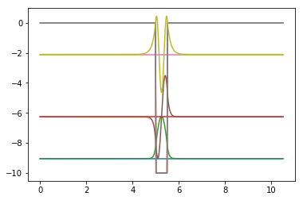

```python
plot_well_wave_funcs(1)
```

For å finne analytiske beregnede energinivåer for potensialet med en brønn brukes den transcendentale ligningen beskrevet i D.J. Griffiths

$$ \tan{z} = \sqrt{(z_0/z)^2 - 1} $$

$z$ er her en funksjon av energien $E$ gitt av

$$ z = \frac{\sqrt{2m(E+V_0}}{\hbar}a, $$

hvor $a$ er halvparten av brønnbredden. $z_0$ er et mål på størrelsen av brønnen og er gitt som

$$ z_0 = \frac{a}{\hbar} \sqrt{2 m V_0}. $$

For å beregne energinivåene løses den transcendentale ligningen numerisk for $z$, som så løses med hensyn på $E$. Dette gjøres i skriptet i neste celle.

```
Energi #1:  -9.038957100851231
Energi #2:  -6.244717176021442
Energi #3:  -2.049505532565955
Num energies:  -9.043560659888897
Num energies:  -6.268381845422539
Num energies:  -2.104781711697484
```

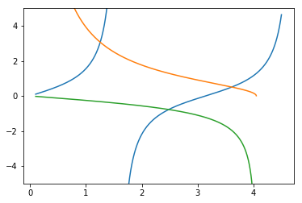

```python
# Numerically computes the energies from the analytic solutions of TISE and prints them
def transcendent_sol():
	a = L_well/2

	z0 = (a/hbar)*np.sqrt(2*m_e*V0*eV)

	RS = lambda z : np.sqrt((z0/z)**2 -1)
	RS_asym = lambda z : -1/(np.sqrt((z0/z)**2 -1))
	LS = lambda z : np.tan(z)

	z_tan = np.linspace(0.1,4.5, 1000)
	z = np.linspace(0.1,4.05, 1000)
	for i in range(len(z_tan)):
		if np.absolute(LS(z_tan[i])) > 9:
			z_tan[i] = np.nan

	f = lambda z : RS(z) - LS(z)
	f_asym = lambda z : RS_asym(z) - LS(z)

	z_zeros = np.array([1.2, 3.5])
	z_zeros = fsolve(f, z_zeros)

	z_zeros_asym = 2
	z_zeros_asym = fsolve(f_asym, z_zeros_asym)

	z_zeros = np.array([z_zeros[0], z_zeros_asym[0], z_zeros[1]])

	E = lambda z : ((z*hbar)**2)/((a**2)*2*m_e*eV) - V0 # Okay, still not perf. div by a**2 arbitrarily to get the energies to match, but someone should figure this out later.
	for i in range(len(z_zeros)):
		print("Energi #" + str(i+1) + ": ", E(z_zeros[i]))

	energies,_,_,_,_,_ = analyze(1)
	for i in range(3):
		print("Num energies: ", energies[i])

	plt.ylim(-5, 5)
	plt.plot(z_tan, LS(z_tan))
	plt.plot(z, RS(z))
	plt.plot(z, RS_asym(z))
	#plt.savefig("trancend_plot.pdf")
	plt.show()

	#return z_zeros

transcendent_sol()
```

Skjæringspunktene mellom $\tan{z}$ (de blå linjene) og $\sqrt{(z_0/z)^2 - 1}$ viser for hvilke $z$ det eksisterer et energinivå som dermed kan løses for $E$. Skriptet over printer også ut både de analytiske og numeriske egenenergiverdiene som stemmer meget bra med hverandre.

Ved plotte samme modell med flere energinivå kan de ubundne tilstandene undersøkes.

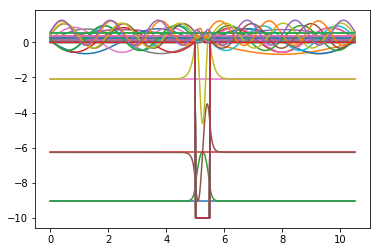

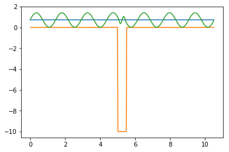

```python
plot_well_wave_funcs(1, 12)
plot_well_wave_funcs(1, 12, 15, 16)
```

Det første plottet viser 12 ekstra energinivå som danner et "kvasikontinuerlig" spektrum av ubundne tilstander for $E>0$. I det neste plottet ser vi kun på den øverste av disse energinivåene. Ved inspeksjon kommer det frem at bølgelengden er mindre innenfor brønnområdet enn utenfor. Impulsen til elektronet kan ved de Broglie-bølgelengden, $\lambda$, skrives som $$ p = \frac{2 \pi \hbar}{\lambda}, $$

og dette viser at elektronets kinetiske energi burde være høyere innenfor brønnen enn utenfor. Dette samsvarer med potensialet og at elektronets totalenergi er konstant for hvert energinivå.

For tre bundne tilstander vil det være mulig å fylle orbitalene med opptil seks elektroner som betyr at atomer med atomnummer 1 til 6 er aktuelle. I grunntilstanden til hvert atom med partall antall elektroner, slik som helium og karbon, vil elektronspinnet til atomet være null. Ved odde antall elektroner, som i hydrogen og lithium, blir elektronspinnet $S = \frac{\sqrt{3}}{2}\hbar$.

## Molekyler

Som det ble nevnt innledningsvis, modellerer vi potensialet for molekyler ved å sette sammen flere endelige enkeltbrønner inne i et bokspotensial, vi ser her på homonukleære, toatomige molekyler, og som for atommodellen er det et $10\omega$ bredt område med nullpotensiale på hver side av brønnene. Bredde og dybde for brønnene, samt barrierebredden, er også som tidligere nevnt.

Under plottes potensialene med både en og to brønner, med tilhørende energinivåer og bølgefunksjoner.

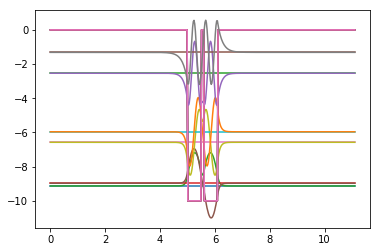

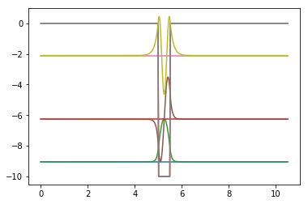

```python
# Plots wave functions and possible energy levels for one and two wells
plot_well_wave_funcs(2)
plot_well_wave_funcs(1)
```

Helium derimot forventes å ha en positiv bindingsenergi, siden det er en edelgass og ikke har lett for å danne bindinger med andre atomer. $He_2$-molekyler har fire elektroner fordelt på laveste bindende og antibindende orbital, og siden differansen mellom grunnenergien til atomet og antibindende orbital er større enn til bindende orbital, vil $He_2$-molekyler ha høyrere energi enn frie $He$ atomer.

Koden i cellen under regner ut bindingsenergiene for modellene våre for $H_2$ og $He_2$. Resultatet viser at vi får negative verdier for begge bindingsenergiene, og vi ser at bindingsenergien for helium er høyere enn for hydrogen, men den er fremdeles negativ. Det antyder at helium naturlig vil binde seg i molekyler, uten energitilførsel, som strider med ovenevnt teori, og det tyder på at modellen vår trolig ikke er presis nok og at energinivåene ikke plasseres helt korrekt.

```python
# Calculates and prints the binding energy of H2 and He2

# H2
energies_H2_well,_,_,_,_,_ = analyze(4)
energies_H_well,_,_,_,_,_ = analyze(2)
bind_energy_H2 = (2*energies_H2_well[0] - 2*energies_H_well[0])

# He2
energies_He2_well,_,_,_,_,_ = analyze(2)
energies_He_well,_,_,_,_,_ = analyze(1)
bind_energy_He2 = (2*energies_He2_well[0] + 2*energies_He2_well[1] - 4*energies_He_well[0])

print("Energi H2: ", energies_H2_well[0])
print("Energi 2H: ", energies_H_well[0])
print("Bindingsenergi: ", bind_energy_H2)
print("")
print("Energi He2: ", energies_He2_well[0])
print("Energi 2He: ", energies_He_well[0])
print("Bindingsenergi: ", bind_energy_He2)
```

```
Energi H2:  -9.18141679910872
Energi 2H:  -9.13153590083726
Bindingsenergi:  -0.09976179654291784

Energi He2:  -9.13153590083726
Energi 2He:  -9.043560659888897
Bindingsenergi:  -0.035690370453508535
```

## Krystaller

På samme måte som vi modelerte toatomige molekyler ved å sette sammen to potensialbrønner, kan vi kvalitativt modellere krystaller ved å sette sammen et stort antall brønner. Vi betegner antall brønner med $N_{\omega}$, og størrelsen på brønnene, barrierene og området rundt er det samme som før.

Med to brønner observerte vi at det ble to bundne tilstander i molekylet for hver bundne tilstand i et enkeltatom. Vi tester med litt ulike verdier av $N_{\omega}$, og i alle tilfellene er antall tilstander for hver av de tre bundne tilstandene i enkeltatomet lik antall brønner. Nedenfor plottes det med fem og ti brønner.

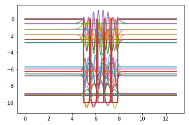

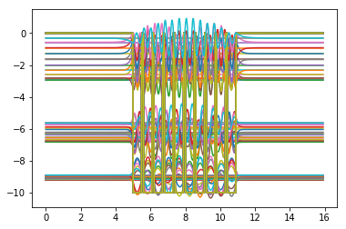

```python
plot_well_wave_funcs(5)
plot_well_wave_funcs(10)
```

Vi ser at båndbredden til energiene også øker med antall brønner, men at tilstandene ligger vesentlig tettere med ti brønner enn med fem. Det tyder på at båndbredden vokser med avtakende hastighet, og at den mulig vil konvergere mot en fast verdi for store $N_{\omega}$

Nedenfor plottes det for et utvalg $N_{\omega}$, og under plottes båndbredden som funksjon av antall brønner, hvor $N_{\omega}$ går fra og med to til hundre.

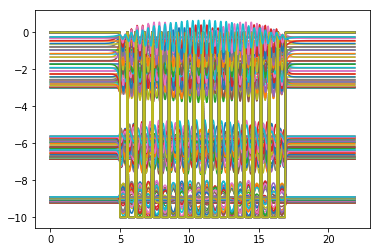

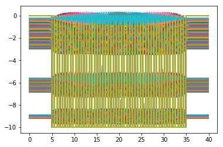

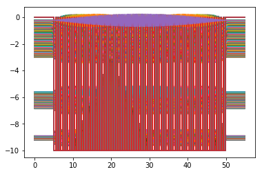

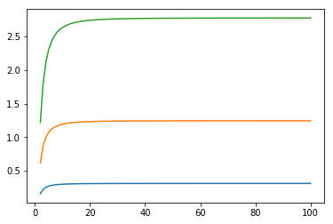

```python
plot_well_wave_funcs(20)
plot_well_wave_funcs(50)
plot_well_wave_funcs(75)
band_widths(2,100)
```

Vi ser av plottene at energinivåene etter hvert, for stort nok antall brønner, ligger helt tett samlet, og det siste plottet viser at bredden på brønnbreddene tydelig konvergerer. Det vil si at en for store $N_{\omega}$ får tilnærmet kontinuerlige energibånd omkring de tre bundne tilstandene for et atom.

Videre ser vi på en krystall modellert med 50 brønner, og vi antar at hvert atom har fire elektroner hver. Det vil si at krystallen har $4*N_{\omega}$ elektroner totalt, som opptar de $2*N_{\omega}$ (pauliprinsippet) tilstandene med lavest energi ved tilstrekkelig lav temperatur. Dette tilsvarer at de to nederste båndene er helt fylt, og energien til de to elektronene med høyest energi tilsvarer den høyeste energien i det andre båndet. Avstanden mellom denne energien og neste tilgjengelige energinivå er derfor avstanden mellom energibånd to og tre, altså krystallens båndgap.

Nedenfor finner vi energien til de øverste elektronene for krystallmodellen vår, samt båndgapet.

```python
energies_crstl, wave_funcs_crstl, x_vec,_,_,_ = analyze(50)
print("Energien til øverste elektron: ", energies_crstl[99])
print("Båndgap: ", energies_crstl[100] - energies_crstl[99])
```

```
Energien til øverste elektron:  -5.617145303265977
Båndgap:  2.6172011862793267
```

Båndgapet er på ca. $2.6 eV$, som betyr at denne krystallen er en halvleder. Det vil si båndgap større enn null, men mindre enn ca. 2-3 eV slik det er beskrevet i prosjektbeskrivelsen.

## Blochs teorem

Blochs teorem sier at løsningen av TUSL i et periodisk potensial med gitterkonstant $\alpha$ er på formen $$ \psi_k(x) = e^{ikx}u_k{x} \quad, hvor \quad u_k(x + \alpha) = u_k(x) $$

Det sier essensielt at absoluttkvadratet av bølgefunksjonene skal ha samme periodisitet som gitteret, og vi forventer derfor at de numeriske løsningene våre er modulerte periodiske funskjoner, med samme periode som brønnpotensialet. Enklere forklart forventer vi at løsningene har like mange topp og bunnpunkter som det er brønner i krystallmodellen.

Når vi skal se om bølge funksjonen følger Blochs teorem er det upraktisk med så mange som 50 brønner, og vi ser derfor nå heller på en modell med 10 brønner.

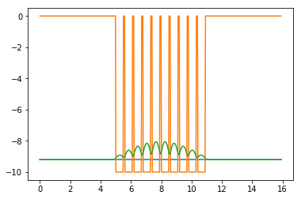

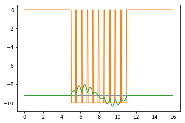

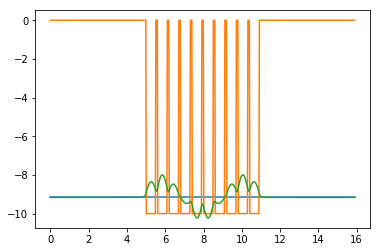

```python
plot_well_wave_funcs(10, 0, 0, 1)
plot_well_wave_funcs(10, 0, 1, 2)
plot_well_wave_funcs(10, 0, 2, 3)
```

Ser av plottene ovenfor at alle de tre første bølgefunksjonene har ett ekstremalpunkt i hver brønn, slik vi forventet ut ifra Blochs teorem, som synes å være oppfylt.

# Konklusjon

Brønnpotensialmodellen viste seg stort sett å gi en god kvalitativ beskrivelse av både atomer, molekyler og krystaller. De numeriske løsningene passet også godt med forventet teori og analytiske løsninger, eneste unntak var bindingsenergien for heliummolekyler. Det vil si at en kan få mye kunnskap om kvantemekanikken, selv med disse enkle modellene.

# Referanser

- Griffiths, D.J. (2018). Introduction to quantum mechanics. 3rd edition. Cambridge University Press.
- Støvneng, J.A. (2019). Fysikkprosjekt: Endimensjonale modeller for atomer, molekyler og krystaller.